# Telecom Customer Churn

**Éverton Bin**  
**Julho, 2020**

## Índice

**Introdução**

**Carregando os Dados**

**Análise Exploratória**

**Pré-Processamento de Dados**

**Equalização de Variáveis**

**Exclusão de Variáveis**

**Tratamento de Variáveis do Tipo Classe**

**Normalização dos Dados**

**Feature Selection - Seleção de Variáveis**

**Balanceamento dos Dados - SMOTE**

**Modelos Preditivos**

**Criando e Treinando os Modelos Preditivos**

**Avaliando os Modelos Preditivos**

**Conclusão**

## 1- Introdução

É cada vez mais comum encontrarmos empresas que se baseiam no modelo de negócio chamado de *Saas* ou *Software as a Service* que, incialmente, era o termo usado para definir, por exemplo, programas que eram vendidos no formato de licensa temporária, mas que, com o advento de serviços de assinatura nos mais diversos segmentos, passou a ser utilizado num sentido mais amplo. Como se trata de uma espécia de aluguel de um produto ou serviço, a saúde da empresa estará diretamente ligada ao chamado *Customer Churn*, conceito este que poderia ser explicado como sendo a taxa de cancelamento por parte dos clientes associada a um determinado período de tempo.

Neste estudo, vamos utilizar o dataset referente a uma empresa do ramo de Telecom fornecido pela [Data Science Academy](https://www.datascienceacademy.com.br/) dentro do programa "Formação Cientista de Dados", como sendo um dos projetos propostos para serem desenvolvidos pelos alunos da plataforma ao longo da formação. O objetivo é criar um modelo de aprendizado de máquina capaz de prever ser um cliente pode ou não cancelar o seu plano e qual é a probabilidade relativa a ambas as possibilidades.

O conjunto de dados fornecido apresenta 20 variáveis, sendo elas:

*state*: estado de residência do cliente;

*account_length*: duração da conta;

*area_code*: código de área;

*international_plan*: se o cliente possui ou não um plano internacional;

*voice_mail_plan*: se o cliente possui ou não um plano de "voice mail";

*number_vmail_messages*: número de mensagens do tipo "voice mail";

*total_day_minutes*: minutos totais em horário comercial;

*total_day_calls*: total de chamadas em horário comercial;

*total_day_charge*: gasto total em horário comercial;

*total_eve_minutes*: minutos totais pós horário comercial;

*total_eve_calls*: total de chamadas pós horário comercial;

*total_eve_charge*: gasto total pós horário comercial;

*total_night_minutes*: minutos totais durante a noite;

*total_night_calls*: total de chamadas durante a noite;

*total_night_charge*: gasto total durante a noite;

*total_intl_minutes*: minutos totais de chamadas internacionais;

*total_intl_calls*: total de chamadas internacionais;

*total_intl_charge*: gasto total com chamadas internacionais;

*number_customer_service_calls*: número de ligações para serviço de atendimento ao cliente;

*churn*: se o cliente cancelou ou não o seu plano.

Baseado nos dados fornecidos, também tentaremos responder a alguns questionamentos que podem nos trazer insights interessantes sobre a situação dos clientes desta empresa de Telecom:

Quais são os estados com maior número de cancelamentos?

Quais são os estados com mais clientes fiéis?

Qual é a diferença de gasto médio total entre clientes que cancelaram e os que não cancelaram seus planos?

Proporcionalmente, clientes que cancelam ligam mais vezes para os serviços de atendimento do que os demais clientes?

## 2- Carregando os Dados

```python
# Pacotes utilizados:
import pandas as pd
import matplotlib.pyplot as plt
import seaborn as sns
%matplotlib inline

import warnings
warnings.filterwarnings('ignore')

from sklearn.preprocessing import MinMaxScaler
from imblearn.over_sampling import SMOTE

from sklearn.model_selection import train_test_split
from sklearn.metrics import accuracy_score, confusion_matrix, plot_confusion_matrix
from sklearn.linear_model import LogisticRegression
from xgboost import XGBClassifier
from sklearn.svm import SVC
from sklearn.model_selection import GridSearchCV
```

```python
# Leitura do arquivo:
cust_churn = pd.read_csv('projeto4_telecom_treino.csv')
```

```python
cust_churn.head()
```

|  | Unnamed: 0 | state | account_length | area_code | international_plan | voice_mail_plan | number_vmail_messages | total_day_minutes | total_day_calls | total_day_charge | ... | total_eve_calls | total_eve_charge | total_night_minutes | total_night_calls | total_night_charge | total_intl_minutes | total_intl_calls | total_intl_charge | number_customer_service_calls | churn |
| --- | --- | --- | --- | --- | --- | --- | --- | --- | --- | --- | --- | --- | --- | --- | --- | --- | --- | --- | --- | --- | --- |
| 0 | 1 | KS | 128 | area_code_415 | no | yes | 25 | 265.1 | 110 | 45.07 | ... | 99 | 16.78 | 244.7 | 91 | 11.01 | 10.0 | 3 | 2.70 | 1 | no |
| 1 | 2 | OH | 107 | area_code_415 | no | yes | 26 | 161.6 | 123 | 27.47 | ... | 103 | 16.62 | 254.4 | 103 | 11.45 | 13.7 | 3 | 3.70 | 1 | no |
| 2 | 3 | NJ | 137 | area_code_415 | no | no | 0 | 243.4 | 114 | 41.38 | ... | 110 | 10.30 | 162.6 | 104 | 7.32 | 12.2 | 5 | 3.29 | 0 | no |
| 3 | 4 | OH | 84 | area_code_408 | yes | no | 0 | 299.4 | 71 | 50.90 | ... | 88 | 5.26 | 196.9 | 89 | 8.86 | 6.6 | 7 | 1.78 | 2 | no |
| 4 | 5 | OK | 75 | area_code_415 | yes | no | 0 | 166.7 | 113 | 28.34 | ... | 122 | 12.61 | 186.9 | 121 | 8.41 | 10.1 | 3 | 2.73 | 3 | no |

5 rows × 21 columns

```python
cust_churn.dtypes
```

```
Unnamed: 0                         int64
state                             object
account_length                     int64
area_code                         object
international_plan                object
voice_mail_plan                   object
number_vmail_messages              int64
total_day_minutes                float64
total_day_calls                    int64
total_day_charge                 float64
total_eve_minutes                float64
total_eve_calls                    int64
total_eve_charge                 float64
total_night_minutes              float64
total_night_calls                  int64
total_night_charge               float64
total_intl_minutes               float64
total_intl_calls                   int64
total_intl_charge                float64
number_customer_service_calls      int64
churn                             object
dtype: object
```

Vamos excluir a primeira variável (sem nome), pois ela não será necessária:

```python
# Excluindo a variável "unnamed":
cust_churn = cust_churn.drop(cust_churn.iloc[:, [0]], axis = 1)
```

## 3- Análise Exploratória

Com os dados carregados, daremos início ao processo de análise exploratória com intuito de extrair informações do conjunto de dados fornecidos. Vamos focar em responder as questões apresentadas na introdução deste estudo.

Antes disso, faremos um resumo estatístico das variáveis para termos uma ideia da variação destes atributos:

```python
cust_churn.iloc[:, 0:12].describe()
```

|  | account_length | number_vmail_messages | total_day_minutes | total_day_calls | total_day_charge | total_eve_minutes | total_eve_calls | total_eve_charge |
| --- | --- | --- | --- | --- | --- | --- | --- | --- |
| count | 3333.000000 | 3333.000000 | 3333.000000 | 3333.000000 | 3333.000000 | 3333.000000 | 3333.000000 | 3333.000000 |
| mean | 101.064806 | 8.099010 | 179.775098 | 100.435644 | 30.562307 | 200.980348 | 100.114311 | 17.083540 |
| std | 39.822106 | 13.688365 | 54.467389 | 20.069084 | 9.259435 | 50.713844 | 19.922625 | 4.310668 |
| min | 1.000000 | 0.000000 | 0.000000 | 0.000000 | 0.000000 | 0.000000 | 0.000000 | 0.000000 |
| 25% | 74.000000 | 0.000000 | 143.700000 | 87.000000 | 24.430000 | 166.600000 | 87.000000 | 14.160000 |
| 50% | 101.000000 | 0.000000 | 179.400000 | 101.000000 | 30.500000 | 201.400000 | 100.000000 | 17.120000 |
| 75% | 127.000000 | 20.000000 | 216.400000 | 114.000000 | 36.790000 | 235.300000 | 114.000000 | 20.000000 |
| max | 243.000000 | 51.000000 | 350.800000 | 165.000000 | 59.640000 | 363.700000 | 170.000000 | 30.910000 |

```python
cust_churn.iloc[:, 12:].describe()
```

|  | total_night_minutes | total_night_calls | total_night_charge | total_intl_minutes | total_intl_calls | total_intl_charge | number_customer_service_calls |
| --- | --- | --- | --- | --- | --- | --- | --- |
| count | 3333.000000 | 3333.000000 | 3333.000000 | 3333.000000 | 3333.000000 | 3333.000000 | 3333.000000 |
| mean | 200.872037 | 100.107711 | 9.039325 | 10.237294 | 4.479448 | 2.764581 | 1.562856 |
| std | 50.573847 | 19.568609 | 2.275873 | 2.791840 | 2.461214 | 0.753773 | 1.315491 |
| min | 23.200000 | 33.000000 | 1.040000 | 0.000000 | 0.000000 | 0.000000 | 0.000000 |
| 25% | 167.000000 | 87.000000 | 7.520000 | 8.500000 | 3.000000 | 2.300000 | 1.000000 |
| 50% | 201.200000 | 100.000000 | 9.050000 | 10.300000 | 4.000000 | 2.780000 | 1.000000 |
| 75% | 235.300000 | 113.000000 | 10.590000 | 12.100000 | 6.000000 | 3.270000 | 2.000000 |
| max | 395.000000 | 175.000000 | 17.770000 | 20.000000 | 20.000000 | 5.400000 | 9.000000 |

Vamos criar subsets, dividindo o conjunto de dados original entre as observações de cancelamento e não cancelamento para, então, criarmos um gráfico de contagem do número de ocorrências de cancelamento ou não cancelamento por estado:

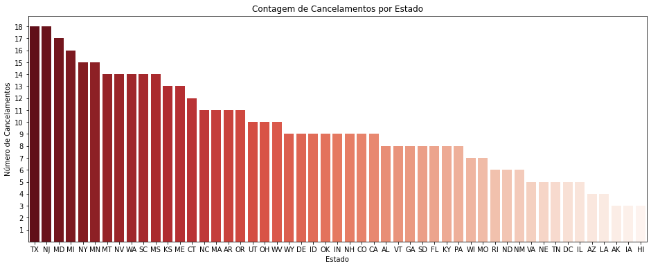

```python
# Criando o subset de observações de cancelamento:
churn_y = cust_churn[cust_churn['churn'] == 'yes']

# Criando o gráfico de contagem de cancelamentos por estado:
fig, ax = plt.subplots(nrows = 1, ncols = 1, figsize = (16, 6))
plt.yticks([1, 2, 3, 4, 5, 6, 7, 8, 9, 10, 11, 12, 13, 14, 15, 16, 17, 18, 19, 20])
sns.countplot(x = 'state', order = churn_y['state'].value_counts().index, data = churn_y, palette = 'Reds_r').set(
    xlabel = 'Estado',
    ylabel = 'Número de Cancelamentos',
    title = 'Contagem de Cancelamentos por Estado')
fig.show()
```

Podemos observar que, em números absolutos, os estados do **Texas** e **New Jersey** empatam com o maior número de ocorrências de cancelamento neste conjunto de dados. **Maryland**, **Michigan** e, empatados, **Minnesota** e **New York** completam o ranking de estados com maior número absoluto de clientes que cancelaram seus planos com a empresa.

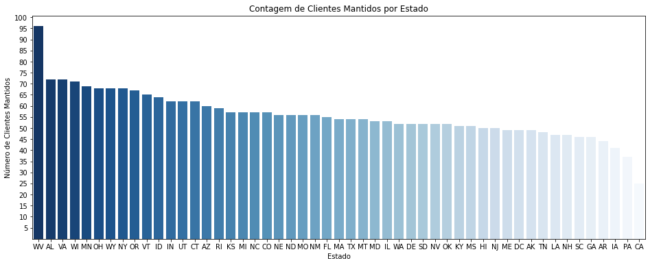

```python
# Criando o subset de observações de não cancelamento:
churn_n = cust_churn[cust_churn['churn'] == 'no']

# Criando o gráfico de contagem de não cancelamentos por estado:
fig, ax = plt.subplots(nrows = 1, ncols = 1, figsize = (16, 6))
plt.yticks([5, 10, 15, 20, 25, 30, 35, 40, 45, 50, 55, 60, 65, 70, 75, 80, 85, 90, 95, 100])
sns.countplot(x = 'state', order = churn_n['state'].value_counts().index, data = churn_n, palette = 'Blues_r').set(
    xlabel = 'Estado',
    ylabel = 'Número de Clientes Mantidos',
    title = 'Contagem de Clientes Mantidos por Estado')
fig.show()
```

Entre os clientes que foram mantidos no período de abrangência do conjunto de dados, o estado de **West Virginia** se destaca muito em relação aos demais estados. O ranking positivo se completa com os estados de **Virginia**, **Alabama**, **Wisconsin** e **Minnesota**, sendo que estes estados apresentam números muito semelhantes.

Agora vamos avaliar a relação do gasto dos clientes com o cancelamento da conta:

```python
# Selecionando as colunas que indicam tempo de contrato, gasto do cliente e se o cancelamento ocorreu:
cust_charge = cust_churn[['account_length', 'total_day_charge', 'total_eve_charge', 'total_night_charge', \
                          'total_intl_charge', 'churn']]

# Transformando as variáveis para obtermos o gasto médio diário dos clientes:
cust_charge['avg_day_charge'] = cust_charge['total_day_charge'] / cust_charge['account_length']
cust_charge['avg_eve_charge'] = cust_charge['total_eve_charge'] / cust_charge['account_length']
cust_charge['avg_night_charge'] = cust_charge['total_night_charge'] / cust_charge['account_length']
cust_charge['avg_intl_charge'] = cust_charge['total_intl_charge'] / cust_charge['account_length']

# Selecionando as novas variáveis e agrupando-as pelo "churn" e calculando os gastos médios dos clientes:
cust_charge_mean = cust_charge[['churn', 'avg_day_charge', 'avg_eve_charge', 'avg_night_charge', \
                                'avg_intl_charge']].groupby(['churn'], as_index = False).mean()
cust_charge_mean['avg_total'] = cust_charge_mean['avg_day_charge'] + cust_charge_mean['avg_eve_charge'] + \
                                cust_charge_mean['avg_night_charge'] + cust_charge_mean['avg_intl_charge']

# Visualizando o dataset tranformado:
cust_charge_mean
```

|  | churn | avg_day_charge | avg_eve_charge | avg_night_charge | avg_intl_charge | avg_total |
| --- | --- | --- | --- | --- | --- | --- |
| 0 | no | 0.470234 | 0.271583 | 0.142873 | 0.042243 | 0.926933 |
| 1 | yes | 0.517043 | 0.255093 | 0.136683 | 0.043310 | 0.952130 |

Para melhor visualização, vamos criar gráficos que mostram o gasto médio diário discriminado por clientes que cancelaram e que não cancelaram suas contas com a empresa. Vamos visualizar o gasto por horário do dia bem como o gasto diário total:

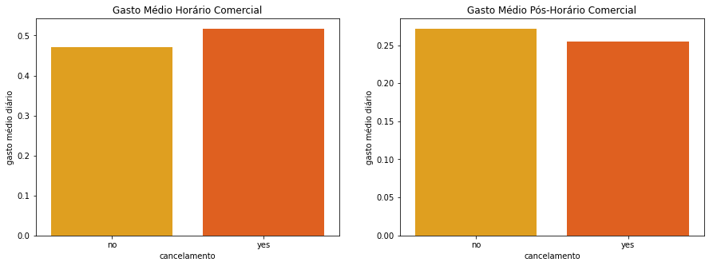

```python
# Criando o gráfico:
fig, ax = plt.subplots(nrows = 1, ncols = 2, figsize = (15, 5))

sns.barplot(x = 'churn', y = 'avg_day_charge', data = cust_charge_mean, ci = None,
            palette = 'autumn_r', ax = ax[0]).set_title('Gasto Médio Horário Comercial')
ax[0].set_xlabel('cancelamento')
ax[0].set_ylabel('gasto médio diário')

sns.barplot(x = 'churn', y = 'avg_eve_charge', data = cust_charge_mean, ci = None,
            palette = 'autumn_r', ax = ax[1]).set_title('Gasto Médio Pós-Horário Comercial')
ax[1].set_xlabel('cancelamento')
ax[1].set_ylabel('gasto médio diário')

fig.show()
```

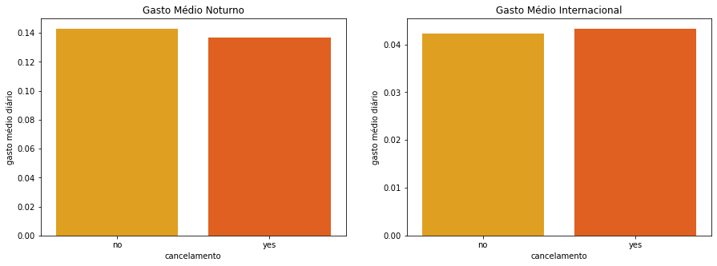

```python
# Criando o gráfico:
fig, ax = plt.subplots(nrows = 1, ncols = 2, figsize = (15, 5))

sns.barplot(x = 'churn', y = 'avg_night_charge', data = cust_charge_mean, ci = None,
            palette = 'autumn_r', ax = ax[0]).set_title('Gasto Médio Noturno')
ax[0].set_xlabel('cancelamento')
ax[0].set_ylabel('gasto médio diário')

sns.barplot(x = 'churn', y = 'avg_intl_charge', data = cust_charge_mean, ci = None,
            palette = 'autumn_r', ax = ax[1]).set_title('Gasto Médio Internacional')
ax[1].set_xlabel('cancelamento')
ax[1].set_ylabel('gasto médio diário')

fig.show()
```

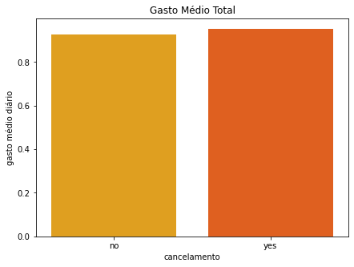

```python
# Criando o gráfico:
fig, ax = plt.subplots(nrows = 1, ncols = 1, figsize = (7, 5))

sns.barplot(x = 'churn', y = 'avg_total', data = cust_charge_mean, ci = None,
            palette = 'autumn_r').set_title('Gasto Médio Total')
ax.set_xlabel('cancelamento')
ax.set_ylabel('gasto médio diário')

fig.show()
```

Podemos observar que os clientes que cancelaram têm um gasto médio mais elevado em horário comercial e com ligações internacionais. O gasto médio diário é levemente menor nos demais horários. Somando os gastos relativos a todos os períodos, pode-se observar que os clientes que solicitaram o cancelamento dos serviços têm um gasto médio maior que os clientes que permaneceram.

Embora não se possa afirmar que existe uma relação de causalidade entre gasto médio e cancelamento, é possível ter uma ideia do perfil dos clientes com potencial para cancelar a relação com a empresa, sendo que este perfil tem a tendência de ser caracterizado pelo maior gasto com ligações em horário comercial e com ligações internacionais.

O próximo passo é analisar as ligações para o SAC - Serviço de Atendimento ao Consumidor:

```python
# Selecionando as colunas que indicam se o cancelamento ocorreu, o tempo de contrato, e o número de ligações ao SAC:
cust_serv_calls = cust_churn[['churn', 'account_length', 'number_customer_service_calls']]

# Criando uma variável que indica o número de ligação para um período de 100 dias:
cust_serv_calls['calls_per_100_days'] = (cust_serv_calls['number_customer_service_calls'] / \
                                         cust_serv_calls['account_length'])*100

# Agrupando o subset pelo "churn" e retornando a média geral de ligações ao SAC e a média de ligações ao SAC por 100 dias:
cust_serv_calls = cust_serv_calls[['churn', 'number_customer_service_calls', \
                                   'calls_per_100_days']].groupby(['churn'], as_index = False).mean()

# Arredondando valores:
cust_serv_calls['number_customer_service_calls'] = cust_serv_calls['number_customer_service_calls'].round(decimals = 2)
cust_serv_calls['calls_per_100_days'] = cust_serv_calls['calls_per_100_days'].round(decimals = 2)

# Visualizando o subset transformando:
cust_serv_calls
```

|  | churn | number_customer_service_calls | calls_per_100_days |
| --- | --- | --- | --- |
| 0 | no | 1.45 | 2.21 |
| 1 | yes | 2.23 | 3.86 |

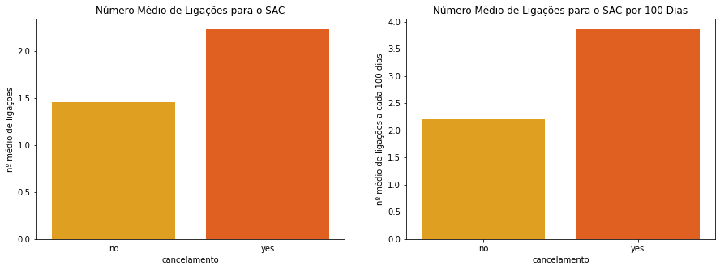

```python
# Criando um gráfico para diferença entre o número de ligações para clientes que cancelaram e não cancelaram seus planos:
fig, ax = plt.subplots(nrows = 1, ncols = 2, figsize = (15, 5))

sns.barplot(x = 'churn', y = 'number_customer_service_calls', data = cust_serv_calls, ci = None,
            palette = 'autumn_r', ax = ax[0]).set_title('Número Médio de Ligações para o SAC')
ax[0].set_xlabel('cancelamento')
ax[0].set_ylabel('nº médio de ligações')

sns.barplot(x = 'churn', y = 'calls_per_100_days', data = cust_serv_calls, ci = None,
            palette = 'autumn_r', ax = ax[1]).set_title('Número Médio de Ligações para o SAC por 100 Dias')
ax[1].set_xlabel('cancelamento')
ax[1].set_ylabel('nº médio de ligações a cada 100 dias')

fig.show()
```

Através desta análise, fica claro que os clientes que cancelaram seus planos ligaram mais vezes para o Serviço de Atendimento ao Consumidor em comparação com os clientes que não fizeram o cancelamento. Na comparação de número de ligações ao SAC por 100 dias, pode-se observar que a proporção de ligações praticamente dobra para o caso dos clientes que efetuaram o cancelamento.

Este fato pode dar um indicativo à empresa de Telecom que o Serviço de Atendimento ao Consumidor pode ser peça chave para evitar que um cliente, de fato, efetue o cancelamento do seu plano, seja melhorando este serviço de atendimento ou fazendo uso deste contato para propor vantagens que possam deixar o cliente mais satisfeito.

## 4- Pré-Processamento de Dados

A partir deste momento, vamos aplicar transformações nos dados com o intuito de melhorar a sua qualidade para que possamos entregar dados mais limpos e expressivos para o algoritmo de machine learning. A ideia é avaliar como os dados se relacionam entre si e com a variável alvo, para que possamos selecionar atributos mais significativos.

Como o conjunto de dados apresenta clientes que permaneceram por períodos distintos, a primeira transformação a ser feita será a "equalização" dos dados, transformando as variáveis que indicam valores totais (ao longo de todo período) para variáveis que indicam valores unitários (por dia). Assim teremos um ponto de partida comum:

### 4.1- Equalização de Variáveis

```python
# Criano uma função para equalizar os dados do dataset:
def equaliza_data(df):
    '''Equaliza as variáveis numéricas e retorna o dataset transformado.

    Args:
    df: dataset a ser transformado.
    '''
    # Criando uma lista das colunas que não serão transformadas:
    no_equaliz = ['state', 'account_length', 'area_code', 'international_plan', 'voice_mail_plan', 'churn']

    # Criano um loop for para transformar as colunas de interesse:
    for i in range(0, len(df.columns)):
        if df.columns[i] not in no_equaliz:
            df[df.columns[i]] = df[df.columns[i]] / df['account_length']

    return df
```

```python
# Aplicando a função ao dataset:
cust_churn_trnsf = equaliza_data(cust_churn)
```

### 4.2- Exclusão de Variáveis

Como a informação da variável *account_length* foi incorporada indiretamente às demais variáveis no item anterior, vamos excluir a variável do conjunto de dados. Da mesma forma, por termos um grande números de estados e códigos de área (classes) em relação ao número de observações, resolvemos excluir também as variáveis *state* e *area_code*:

```python
cust_churn_trnsf = cust_churn_trnsf.drop(['account_length', 'state', 'area_code'], axis = 1)
```

### 4.3- Tratamento de Variáveis do Tipo Classe

Visto que as variáveis *international_plan* e *voice_mail_plan* indicam se o cliente contratou ou não um determinado plano oferecido pela empresa, vamos transformá-las em variáveis numéricas, utilizando **0** para indicar que o cliente não possui o plano e **1** para indicar que o cliente adquiriu o plano oferecido.

Vamos utilizar esta mesma lógica para tratar a variável *churn*, ou seja, **0** indicará que o cliente não cancelou, enquanto **1** indicará que o cancelamento foi efetivado.

```python
# Selecionando as colunas que serão transformadas:
classes = ['international_plan', 'voice_mail_plan', 'churn']

# Aplicando a transformação às colunas:
for column in classes:
    cust_churn_trnsf[column] = cust_churn_trnsf[column].apply(lambda x: 0 if x == "no" else 1)
```

### 4.4- Normalização dos Dados

Ainda que nem todos os algoritmos de aprendizado de máquina necessitem receber os dados normalizados, vamos aplicar o processo de normalização para deixar os dados padronizados em uma mesma escala e poder apresentar os mesmos dados a diferentes algoritmos:

```python
# Criando o objeto scaler:
scaler = MinMaxScaler(feature_range = (0,1))

# Aplicando a padronização aos dados:
cust_churn_padrao = scaler.fit_transform(cust_churn_trnsf)

# Transformando o array criado para dataframe:
cust_churn_padrao = pd.DataFrame(cust_churn_padrao, columns = cust_churn_trnsf.columns)
```

### 4.5- Feature Selection - Seleção de Variáveis

Nesta etapa, vamos avaliar a correlação entre as variáveis para que possamos fazer uma pré-seleção daquelas que possam ser mais relevantes para o processo de construção do modelo de aprendizado:

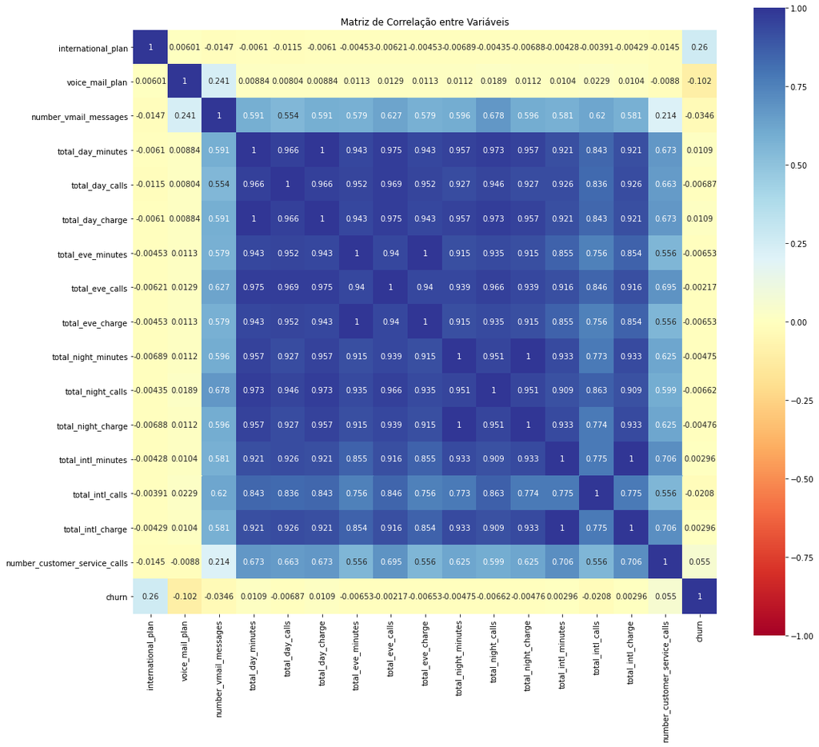

```python
# Calculando a correlação entre as variáveis:
cust_churn_corr = cust_churn_padrao.corr()

# Criando um gráfico da matriz de correlação:
fig, ax = plt.subplots(nrows = 1, ncols = 1, figsize = (17, 15))

sns.heatmap(cust_churn_corr, annot = True, fmt = '.3g', vmin = -1, vmax = 1, center = 0,
                        cmap = 'RdYlBu', square = True)
ax.set_title('Matriz de Correlação entre Variáveis')

fig.show()
```

Como já esperado, pode-se observar pela matriz acima que muitas variáveis apresentam uma correlação muito elevada entre si. Em outras palavras, podemos dizer que elas representam a mesma informação, como no caso, por exemplo, das variáveis *total_day_minutes*, *total_day_calls* e *total_day_charge*. Ou seja, as variáveis não são independentes entre si, pois se aumentássemos o total de minutos, automaticamente estaríamos aumentando o gasto e, provavelmente, teríamos um número maior de ligações.

```python
# Variáveis a serem descartadas:
var_dependentes = ['total_day_minutes', 'total_day_calls', 'total_night_minutes', 'total_night_calls',
                  'total_intl_minutes', 'total_intl_calls']

# Descartando as variáveis:
cust_churn_padrao = cust_churn_padrao.drop(var_dependentes, axis = 1)

# Salvando a lista final de colunas selecionadas:
cols_final = cust_churn_padrao.columns
```

### 4.6- Balanceamento dos Dados - SMOTE

Como queremos que o modelo a ser criado aprenda igualmente sobre duas classes distintas (clientes que cancelam o plano e clientes que não o cancelam), precisamos garantir o balanceamento dos dados, ou seja, precisamos ter um número de observações similares para ambas as classes.

Primeiramente, vamos verificar se o conjunto de dados está desbalanceado:

```python
# Agrupando por classe e contabilizando o número de observações:
cust_churn_padrao.groupby(['churn']).size()
```

```
churn
0.0    2850
1.0     483
dtype: int64
```

Claramente, temos muito mais informações sobre clientes que não cancelaram do que sobre os clientes que efetivamente cancelaram o plano. Sendo assim, vamos aplicar o *SMOTE* para que a proporção de dados de cada classe seja mais proporcional:

```python
# Dividindo os dados em variáveis preditoras e variável target:
X = cust_churn_padrao.iloc[:, :-1]
Y = cust_churn_padrao.iloc[:, -1]

# Aplicando SMOTE aos dados de treino:
sm = SMOTE(random_state = 101)
X_treino, Y_treino = sm.fit_sample(X, Y)
```

## 5- Modelos Preditivos

Nesta etapa, vamos fazer uso do algoritmo de aprendizado chamado *Logistic Regression*. Primeiramente, o modelo será criado para, então, alimentá-lo com os dados de treino. Criaremos outro modelo, utilizando o algoritmo *XGBoost Classifier*, para então compararmos o desempenho dos dois. Ainda uma terceira alternativa será criada, no caso, fazendo uso do algoritmo *SVC*.

Com os modelos treinados, será possível fazer as previsões a partir do conjunto de dados de teste para que, finalmente, possamos avaliar o desempenho de cada um dos modelos na predição das classes desejadas. Sendo assim, vamos carregar os dados de teste que foram fornecidos:

```python
# Carregado o arquivo com o conjunto de dados para teste:
cust_churn_teste = pd.read_csv("projeto4_telecom_teste.csv")
```

Com o arquivo carregado, faremos as mesmas transformações realizadas no conjunto de dados de treino:

```python
# Equalizando os dados:
cust_churn_teste_trnsf = equaliza_data(cust_churn_teste)

# Exclusão de variáveis:
cust_churn_teste_trnsf = cust_churn_teste_trnsf.drop(['account_length', 'state', 'area_code'], axis = 1)

# Tratamento de variáveis do tipo classe:
for column in classes:
    cust_churn_teste_trnsf[column] = cust_churn_teste_trnsf[column].apply(lambda x: 0 if x == "no" else 1)

# Normalização dos dados de teste:
cust_churn_teste_padrao = scaler.fit_transform(cust_churn_teste_trnsf)

# Transformando o array criado para dataframe:
cust_churn_teste_padrao = pd.DataFrame(cust_churn_teste_padrao, columns = cust_churn_teste_trnsf.columns)

# Feature Selection:
cust_churn_teste_padrao = cust_churn_teste_padrao[cols_final]

# Dividindo os dados de teste em variáveis preditoras e variável target:
X_teste = cust_churn_teste_padrao.iloc[:, :-1]
Y_teste = cust_churn_teste_padrao.iloc[:, -1]
```

### 5.1- Criando e Treinando os Modelos Preditivos

Criando o modelo de *Regressão Logística*:

```python
# Criando o modelo de Regressão Logística:
model = LogisticRegression(random_state = 101)

# Treinando o modelo com os dados de treino:
model.fit(X_treino, Y_treino)
```

```
LogisticRegression(random_state=101)
```

Com o modelo treinado, vamos fazer as previsões para os dados de teste:

```python
# Aplicando o modelo aos dados de teste:
Y_pred = model.predict(X_teste)
```

Vamos criar um segundo modelo preditivo, desta vez utilizando o *XGBoost Classifier*:

```python
# Criando o modelo XGBoost Classifier:
model_xgb = XGBClassifier(random_state = 101)

# Treinando o modelo com os dados de treino:
model_xgb.fit(X_treino, Y_treino)
```

```
XGBClassifier(base_score=0.5, booster='gbtree', colsample_bylevel=1,
              colsample_bynode=1, colsample_bytree=1, gamma=0, gpu_id=-1,
              importance_type='gain', interaction_constraints='',
              learning_rate=0.300000012, max_delta_step=0, max_depth=6,
              min_child_weight=1, missing=nan, monotone_constraints='()',
              n_estimators=100, n_jobs=0, num_parallel_tree=1, random_state=101,
              reg_alpha=0, reg_lambda=1, scale_pos_weight=1, subsample=1,
              tree_method='exact', validate_parameters=1, verbosity=None)
```

Da mesma forma que anteriormente, faremos as previsões dos dados de teste, utilizando o novo modelo criado:

```python
# Aplicando o novo modelo aos dados de teste:
Y_pred_xgb = model_xgb.predict(X_teste)
```

Criando nosso terceiro modelo preditivo, desta vez o *Support Vector Classifier*:

```python
# Criando o modelo SVC:
model_svc = SVC(random_state = 101)

# Treinando o modelo com os dados de treino:
model_svc.fit(X_treino, Y_treino)
```

```
SVC(random_state=101)
```

Fazendo as novas previsões com o modelo *SVC*:

```python
# Aplicando o terceiro modelo aos dados de teste:
Y_pred_svc = model_svc.predict(X_teste)
```